# Basic concepts

Kenny

Friday, January 09, 2015

### What is vector

> all vector shall have the elements with same type

> sequence vectors

```r
5:9
```

```
## [1] 5 6 7 8 9
```

```r
seq(5, 9)
```

```
## [1] 5 6 7 8 9
```

```r
seq(5, 9, 0.5)
```

```
## [1] 5.0 5.5 6.0 6.5 7.0 7.5 8.0 8.5 9.0
```

### retrieve values from a vector

```r
sentence <- c('walk', 'the', 'plank')
sentence[3]
```

```
## [1] "plank"
```

```r
sentence[1]  # Many languages start array indices at 0, but R's vector indices start at 1
```

```
## [1] "walk"
```

```r
sentence[3] <- "dog" # assign new values within an existing vector

sentence[4] <- 'to'

sentence[c(1, 3)] # use a vector within the square brackets to access multiple values
```

```
## [1] "walk" "dog"
```

```r
sentence[2:4]  # Get the second through fourth words:
```

```
## [1] "the" "dog" "to"
```

```r
sentence[5:7] <- c('the', 'poop', 'deck')

sentence[6]
```

```
## [1] "poop"
```

### assign names to vector’s elements

```r
ranks <- 1:3
names(ranks) <- c("first", "second", "third") # assign names to elements of a vector
```

### retrieve elements from vector by names

```r
ranks # still vector only with names
```

```
##  first second  third
##      1      2      3
```

```r
ranks["first"] # still a value element of a vector only with a name
```

```
## first
##     1
```

```r
ranks["third"] <- 4 # assign a different value to the element with name "third"
```

### barplot to draw vector

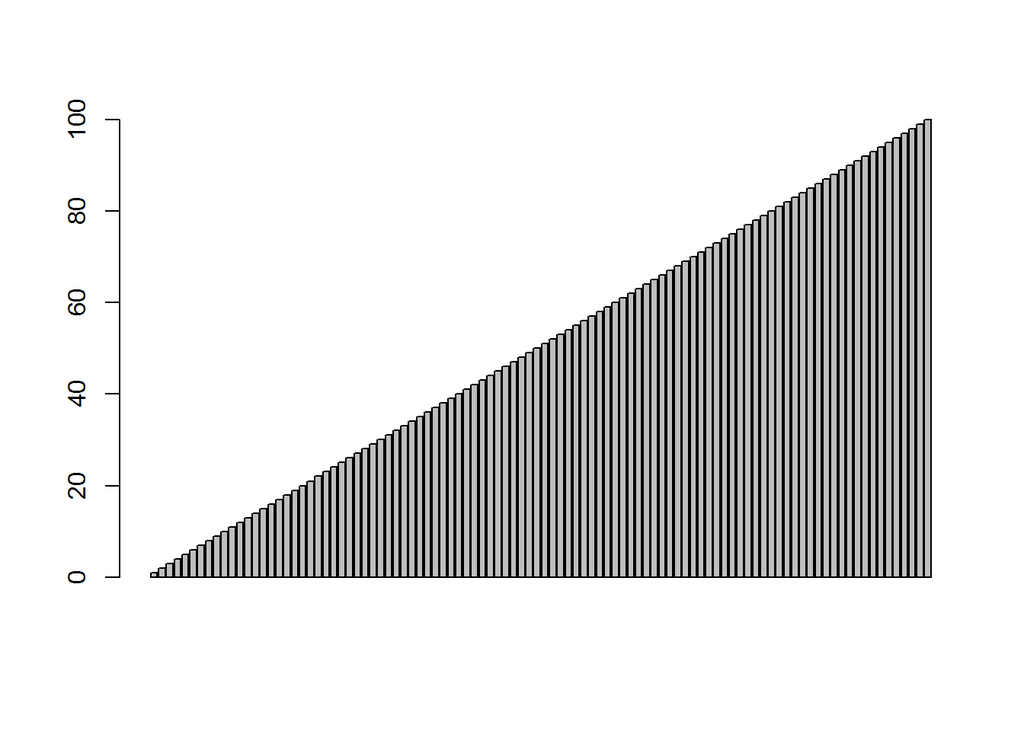

```r
barplot(1:100) # draw bars from vector
```

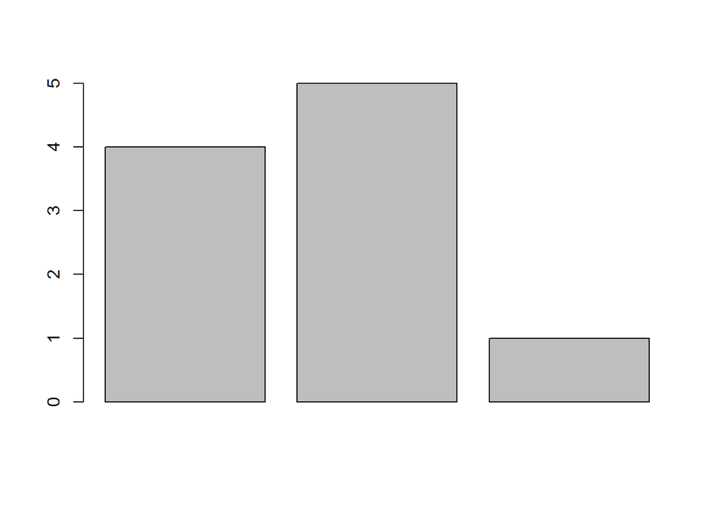

```r
vesselsSunk <- c(4, 5, 1)
barplot(vesselsSunk)
```

> names of vector elements will show on graphs

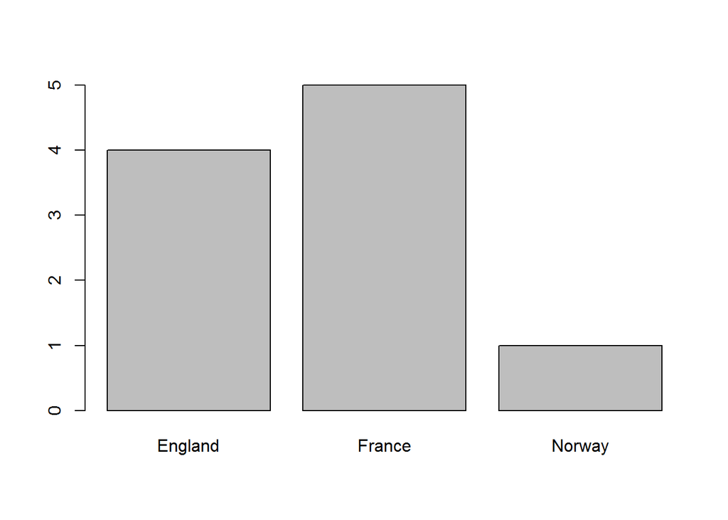

```r
names(vesselsSunk) <- c("England", "France", "Norway")
barplot(vesselsSunk)
```

### Vector math

```r
a <- c(1, 2, 3)
a + 1
```

```
## [1] 2 3 4
```

```r
a == c(1, 99, 3) # each element compare to each element of different vector
```

```
## [1]  TRUE FALSE  TRUE
```

```r
sin(a) # function apply to each element
```

```
## [1] 0.8414710 0.9092974 0.1411200
```

### How to plot two vectors

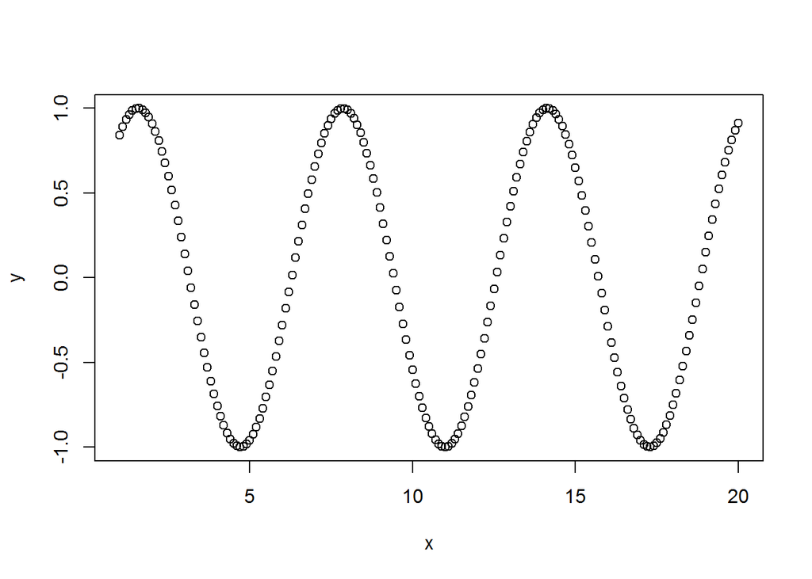

```r
x <- seq(1, 20, 0.1)
y <- sin(x)
plot(x, y)
```

### How to deal with NA

```r
a <- c(1, 3, NA, 7, 9)
sum(a)
```

```
## [1] NA
```

```r
sum(a, na.rm = TRUE)
```

```
## [1] 20
```

### Difference between matrix and array or vector

> A matrix is just a fancy term for a 2-dimensional array

### Build a matrix

```r
matrix(0, 3, 4) # 3 high, 4 wide, with 0 as value
```

```
##      [,1] [,2] [,3] [,4]
## [1,]    0    0    0    0
## [2,]    0    0    0    0
## [3,]    0    0    0    0
```

```r
a <- 1:12
print(a) # prove a is only a vector
```

```
##  [1]  1  2  3  4  5  6  7  8  9 10 11 12
```

```r
matrix(a, 3, 4) # a vector is turned into a matrix
```

```
##      [,1] [,2] [,3] [,4]
## [1,]    1    4    7   10
## [2,]    2    5    8   11
## [3,]    3    6    9   12
```

```r
plank <- 1:8 # a vector or one dimensional array
dim(plank) <- c(2, 4) # give this vector(one dim of array) a two dimension attribute
print(plank) # automatically, the vector is turned into 2-dimension array = matrix
```

```
##      [,1] [,2] [,3] [,4]
## [1,]    1    3    5    7
## [2,]    2    4    6    8
```

```r
matrix(8, 5, 5) # make matrix with matrix() function, it can be 8 or a vector
```

```
##      [,1] [,2] [,3] [,4] [,5]
## [1,]    8    8    8    8    8
## [2,]    8    8    8    8    8
## [3,]    8    8    8    8    8
## [4,]    8    8    8    8    8
## [5,]    8    8    8    8    8
```

```r
plank <- matrix(1:8, 2, 4, byrow = FALSE)
print(plank)
```

```
##      [,1] [,2] [,3] [,4]
## [1,]    1    3    5    7
## [2,]    2    4    6    8
```

### retrieve elements from Matrix

```r
plank[2, 3]  # as matrix is 2 dim, so two number to locate value
```

```
## [1] 6
```

```r
plank[1, 4]
```

```
## [1] 7
```

```r
plank[1, 4] <- 0
plank[2,]
```

```
## [1] 2 4 6 8
```

```r
plank[, 4]
```

```
## [1] 0 8
```

```r
plank[, 2:4]
```

```
##      [,1] [,2] [,3]
## [1,]    3    5    0
## [2,]    4    6    8
```

### matrix plotting

> Text output is only useful when matrices are small. When working with more complex data, we need matrix plotting

> Let’s draw an elevation map of a sandy beach, 1 meter above sea level

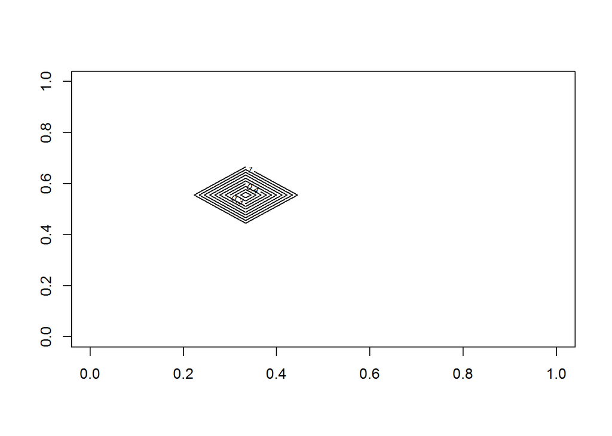

```r
elevation <- matrix(1, 10, 10) # we think of a 3D sandy beach
elevation[4, 6] <- 0 # we dig down 1 meter at a specific place on the beach
contour(elevation) # draw a contour map
```

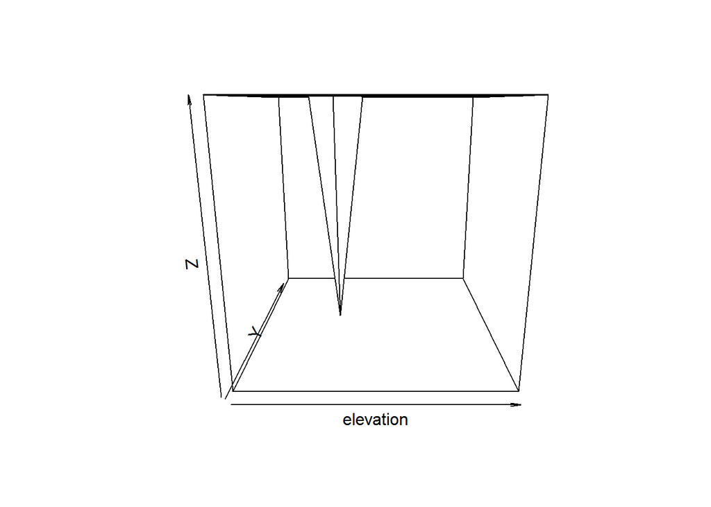

```r
persp(elevation) # draw a 3D map, but persp automatically expands the view so that your highest value (the beach surface) is at the very top
```

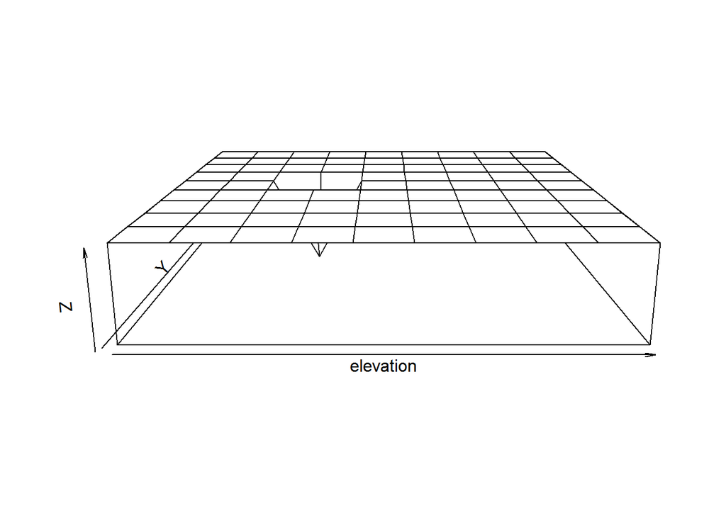

```r
persp(elevation, expand=0.2) # more reasonable graph
```

> a 3D map of a dormant New Zealand volcano

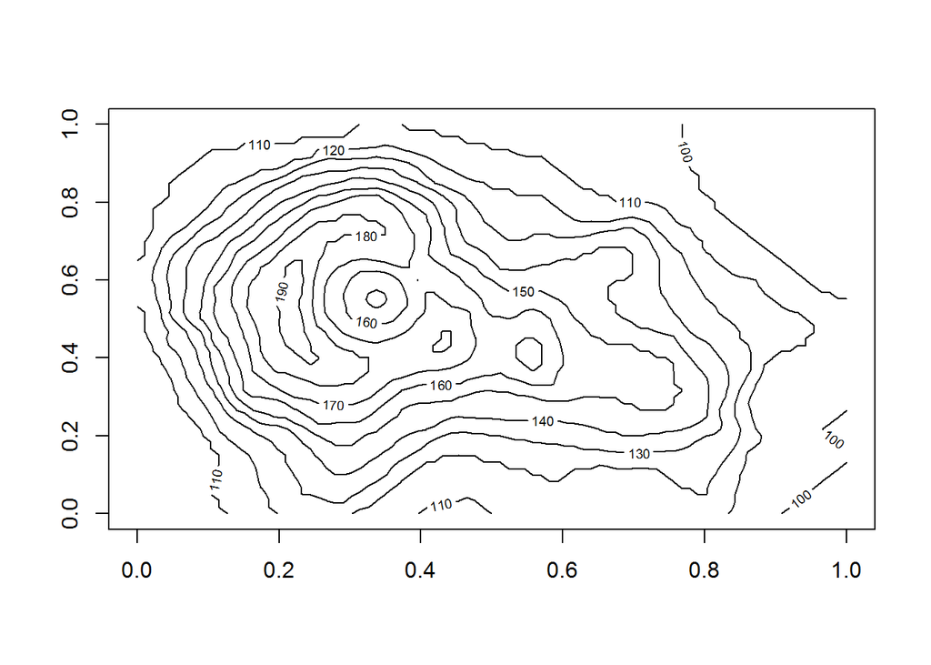

```r
contour(volcano)
```

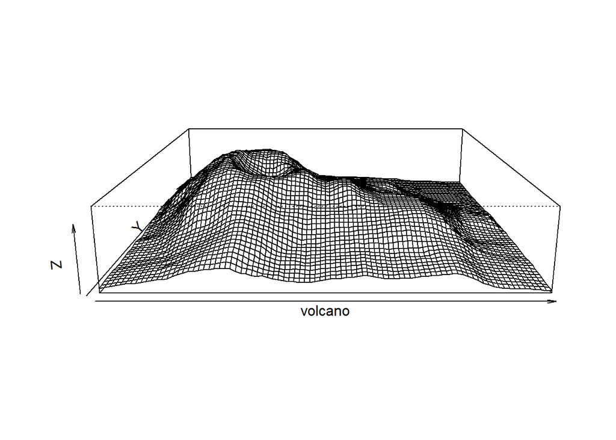

```r
persp(volcano, expand=0.2)
```

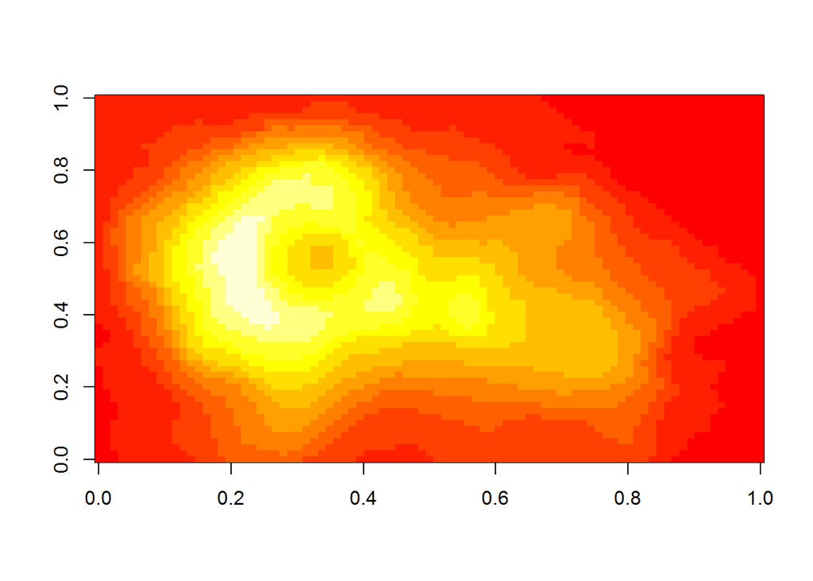

```r
image(volcano)
```

### summary statistics on mean

```r
limbs <- c(4, 3, 4, 3, 2, 4, 4, 4) # collect data about crew members
names(limbs) <- c('One-Eye', 'Peg-Leg', 'Smitty', 'Hook', 'Scooter', 'Dan', 'Mikey', 'Blackbeard')
mean(limbs)
```

```
## [1] 3.5
```

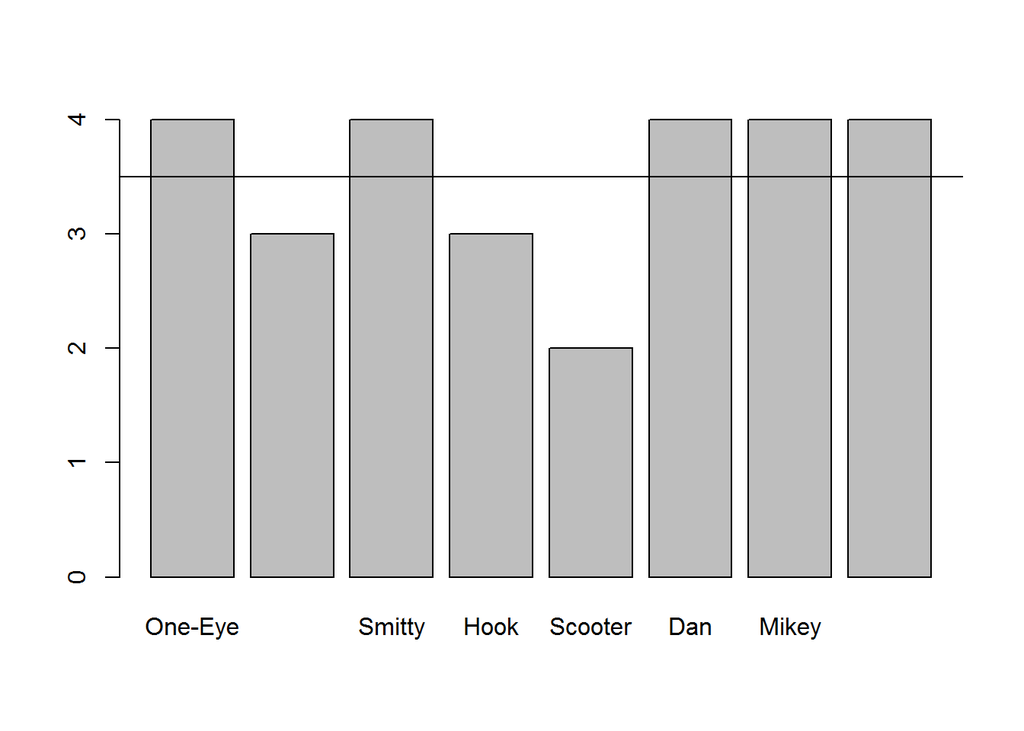

```r
barplot(limbs)
abline(h = mean(limbs)) # draw a horizontal line display mean
```

### graph ablines differ in sd

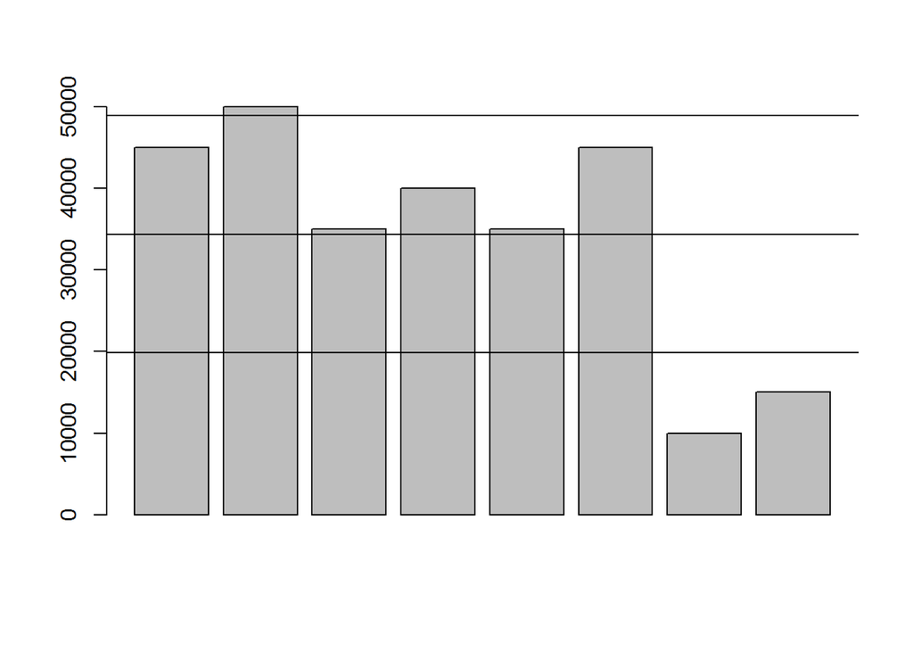

```r
pounds <- c(45000, 50000, 35000, 40000, 35000, 45000, 10000, 15000)
barplot(pounds)
meanValue <- mean(pounds)
abline(h = meanValue) # line on mean value
deviation <- sd(pounds) # value of 1 sd
abline(h = meanValue + deviation) # line on mean + 1sd
abline(h = meanValue - deviation)
```

### Create factors

> Often your data needs to be grouped by category = factors

```r
chests <- c('gold', 'silver', 'gems', 'gold', 'gems')
types <- factor(chests) # character vector turned into factor, no more quotation marks
print(chests) # chests is still the same vector
```

```
## [1] "gold"   "silver" "gems"   "gold"   "gems"
```

```r
print(types) # types is the vector chests with factor or levels attribute
```

```
## [1] gold   silver gems   gold   gems
## Levels: gems gold silver
```

```r
as.integer(types) # values of types are not strings but integer references to one of the factor's levels
```

```
## [1] 2 3 1 2 1
```

```r
levels(types) # but levels themselves are strings or characters, so with quotations
```

```
## [1] "gems"   "gold"   "silver"
```

### graph factors with pch

> graph the chests by weight and value

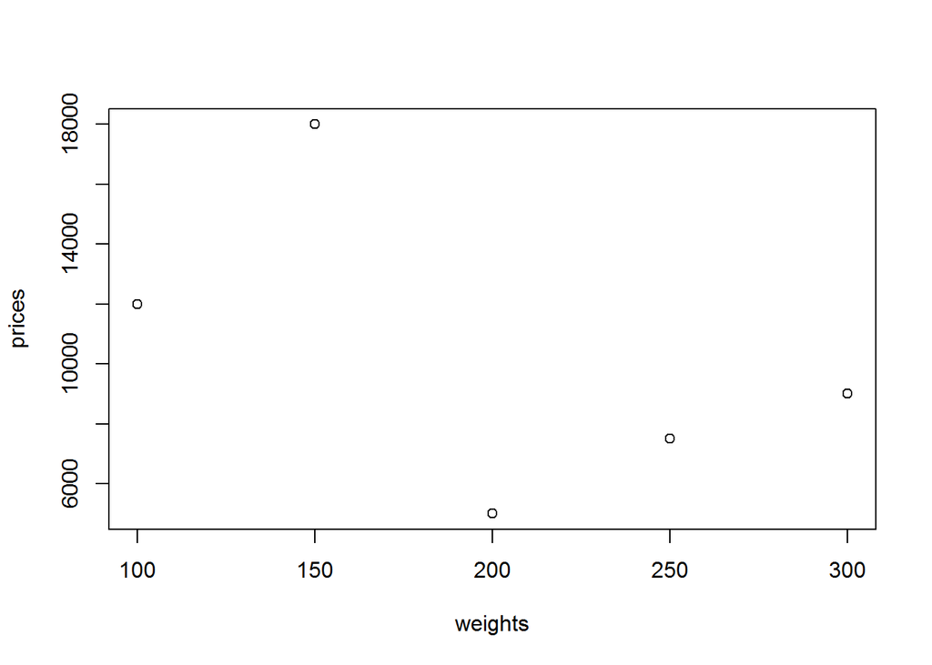

```r
weights <- c(300, 200, 100, 250, 150)
prices <- c(9000, 5000, 12000, 7500, 18000)
plot(weights, prices) # both weights and prices correspond to chests or types
```

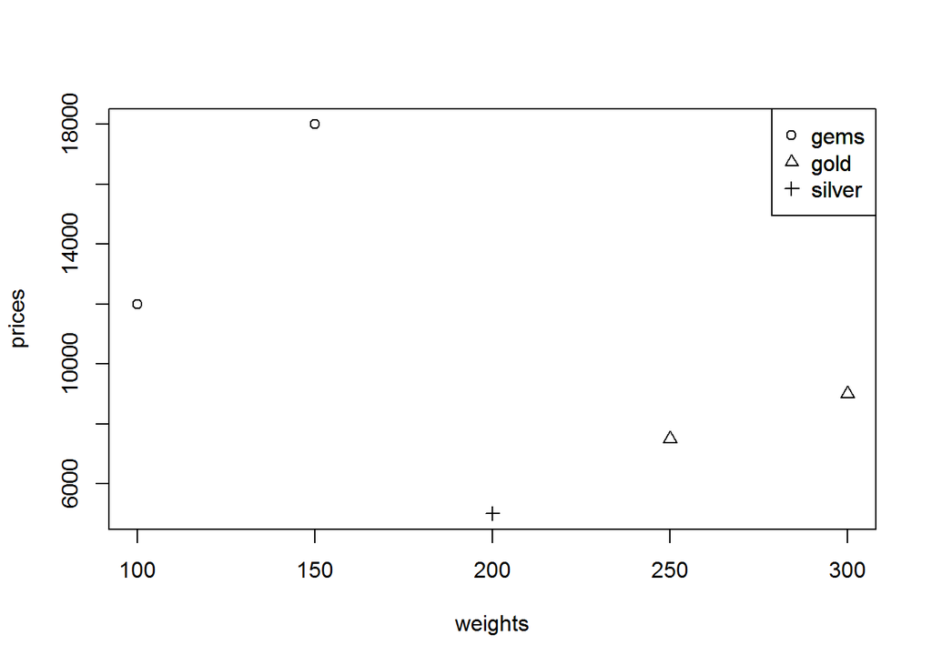

```r
plot(weights, prices, pch=as.integer(types)) # converting the factor to integers, and passing it to the pch argument

legend("topright", c("gems", "gold", "silver"), pch=1:3) # make legends to correspond to pch

legend("topright", levels(types), pch=1:length(levels(types))) # make it automatic given future changes
```

### build dataframe

> 1. same length of all columns
> 2. same type of data within a column
> 3. different type of data among different columns is ok

```r
treasure <- data.frame(weights, prices, types)
print(treasure)
```

```
##   weights prices  types
## 1     300   9000   gold
## 2     200   5000 silver
## 3     100  12000   gems
## 4     250   7500   gold
## 5     150  18000   gems
```

### retrieve column from a dataframe

```r
treasure[[2]] # retrieve the second column
```

```
## [1]  9000  5000 12000  7500 18000
```

```r
treasure[["weights"]] # retrieve the column with name weights
```

```
## [1] 300 200 100 250 150
```

```r
treasure$prices # retrieve the column with name prices
```

```
## [1]  9000  5000 12000  7500 18000
```

```r
treasure[["types"]] # get column named types (a vector of factor)
```

```
## [1] gold   silver gems   gold   gems
## Levels: gems gold silver
```

### read table and csv and make csv directly from notepad

```r
read.csv("targets.csv")
```

```
##          Port Population Worth
## 1   Cartagena      35000 10000
## 2 Porto Bello      49000 15000
## 3      Havana     140000 50000
## 4 Panama City     105000 35000
```

```r
read.table("infantry.txt", sep="\t")
```

```
##                      V1
## 1 Port         Infantry
## 2      Porto Bello  700
## 3      Cartagena    500
## 4     Panama City  1500
## 5     Havana       2000
```

```r
read.table("infantry.txt", sep="\t", header=TRUE)
```

```
##   Port.........Infantry
## 1      Porto Bello  700
## 2      Cartagena    500
## 3     Panama City  1500
## 4     Havana       2000
```

### merge dataframes

```r
targets <- read.csv("targets.csv")
infantry <- read.table("infantry.txt", sep="\t", header=TRUE)
merge(x = targets, y = infantry) # same column melt into one, and different ones combine
```

```
##           Port Population Worth Port.........Infantry
## 1    Cartagena      35000 10000      Porto Bello  700
## 2  Porto Bello      49000 15000      Porto Bello  700
## 3       Havana     140000 50000      Porto Bello  700
## 4  Panama City     105000 35000      Porto Bello  700
## 5    Cartagena      35000 10000      Cartagena    500
## 6  Porto Bello      49000 15000      Cartagena    500
## 7       Havana     140000 50000      Cartagena    500
## 8  Panama City     105000 35000      Cartagena    500
## 9    Cartagena      35000 10000     Panama City  1500
## 10 Porto Bello      49000 15000     Panama City  1500
## 11      Havana     140000 50000     Panama City  1500
## 12 Panama City     105000 35000     Panama City  1500
## 13   Cartagena      35000 10000     Havana       2000
## 14 Porto Bello      49000 15000     Havana       2000
## 15      Havana     140000 50000     Havana       2000
## 16 Panama City     105000 35000     Havana       2000
```

### merge dataframe and real data

[output not shown]

### use ggplot2

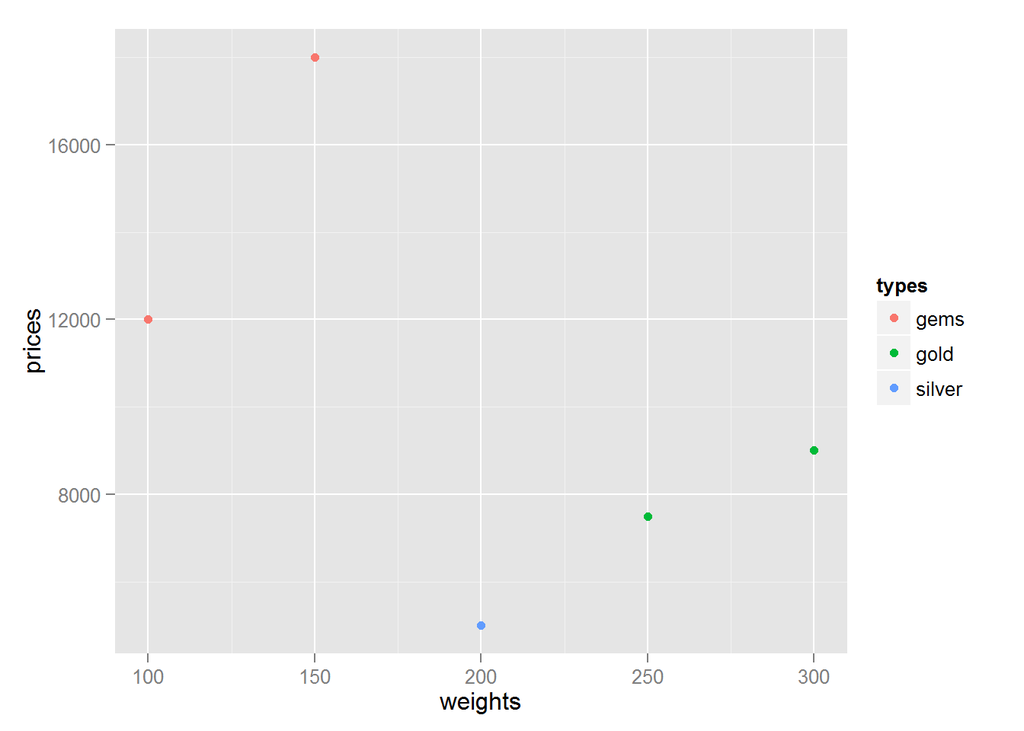

```r
weights <- c(300, 200, 100, 250, 150)
prices <- c(9000, 5000, 12000, 7500, 18000)
chests <- c('gold', 'silver', 'gems', 'gold', 'gems')
types <- factor(chests)
require(ggplot2)
qplot(weights, prices, color = types) # color only accept factor
```

### Why full control of graphics in R can be frustrating

> **There are many graphics systems in R, and they don’t necessarily play well with each other**

**Base graphics**

- is the oldest and most basic. Base graphics produce static pictures
- its par function is used to set up the graphics parameters that control the layout and look of the graphics

**grid**

- is a much more flexible system of graphics.
- there are graph objects (see More R key objects for the idea of “object”).

**lattice**

- contains a set of graphics techniques that are very useful for data analysis.

**ggplot2**

- is a plotting system for R, trying to take the good parts of base and lattice graphics
- It takes care of many fiddly details that make plotting a hassle (like drawing legends)
- provides a powerful model of graphics that makes it easy to produce complex multi-layered graphics.

**Useful links**

- Cran Task View on [graphics](http://cran.r-project.org/web/views/Graphics.html)

### how many different objects in R?

**What is an object?**

- assign a name, if you can, it is; if you cannot assign a name to it, it is not
- something that we can hold, turn upside down, and look at

**What is Attribute?**

- Attributes are spice.
- objects have a main part, but can have one or more attributes
- same bowl of rice and beans, with different spice, they are different dishes.
- name is attribute:
  - The elements of an atomic vector can each have a name.
  - The components of a list can each have a name.
- class is a very important attribute.

**What are inherent characteristics of objects?**

- Objects have a “length”.
  - The length of an atomic vector is the number of elements it has.
  - The length of a list is the number of components that it has.
  - The length of NULL is zero.
- Objects have a “mode”.
  - This says what kind of object they are.
  - mode() function tell you the mode of an object.
  - typeof() function tell slightly more specific about an object.

**What are Atomic Types?**

- There are three atomic types
  - Numeric objects hold numbers.
  - Logical objects have values that are TRUE, FALSE and NA.
  - Character objects have a string as each element.

**What are Matrices and Data Frames?**

- similarities
  - matrices and data frames are rectangular objects with rows and columns.
  - Both are linear structures pretending to be rectangular.
  - Both have names for the rows and the columns.
- differences
  - A matrix is a vector that has a dim attribute.
  - The dim is a vector of two integers saying how many rows and columns there are.
  - A data frame has a class attribute that is “data.frame”.
  - It is really a list with as many components as there are columns.
  - Each component has to have the same number of elements (the number of rows).
  - check with function is.data.frame(x)

**What are Factors?**

- Factors have two key attributes:
  - a class attribute and a levels attribute.
  - The levels is a character vector that gives the possible categories for the object.
  - ???The basic part of the object is a vector of integers that are the location of the category in the levels vector.

**Missing values**

- All of the atomic modes have a missing value.
  - This is printed as NA.
  - test for missing values with the is.na function. For example: is.na(x)

**See inside structure of object**

```r
examp <- list(A=1:10, B=letters, C=list(NULL, TRUE))
str(examp)
```

```
## List of 3
##  $ A: int [1:10] 1 2 3 4 5 6 7 8 9 10
##  $ B: chr [1:26] "a" "b" "c" "d" ...
##  $ C:List of 2
##   ..$ : NULL
##   ..$ : logi TRUE
```

**Function are objects too**

### Watch for integer and floating point

- they differ when floating point is result of rounding

```r
seq(0, 1, by = .1)
```

```
##  [1] 0.0 0.1 0.2 0.3 0.4 0.5 0.6 0.7 0.8 0.9 1.0
```

```r
seq(0, 1, by = .1)[4] # the result is rounding outcome, not the real outcome
```

```
## [1] 0.3
```

```r
seq(0, 1, by = .1)[4] == .3 # therefore it is false not true here
```

```
## [1] FALSE
```

```r
seq(0, 1, by = .1)[4] - .3
```

```
## [1] 5.551115e-17
```

```r
print(seq(0, 1, by=.1)[4], digits=20)
```

```
## [1] 0.30000000000000004441
```

### How to replace . with ,

**replace . with , by format(, decimal.mark=)**

```r
format(seq(0, 1, by=.5), decimal.mark=",") # change to , by format(x, decimal.mark = ",")
```

```
## [1] "0,0" "0,5" "1,0"
```

**replace . with , by option at beginning**

```r
options(OutDec=",")
seq(0, 1, by=.5)
```

```
## [1] 0,0 0,5 1,0
```

**use sub() to replace . with ,**

```r
nums <- format(seq(0, 1, by=.5), decimal.mark=",") # , makes number into strings
nums
```

```
## [1] "0,0" "0,5" "1,0"
```

```r
sub(",", ".", nums) # sub() work with strings?
```

```
## [1] "0.0" "0.5" "1.0"
```

```r
as.numeric(sub(",", ".", nums)) # turn string into numbers again
```

```
## [1] 0,0 0,5 1,0
```

**replace multiple , with nothing**

```r
as.numeric(gsub(",", "", "2,300,000"))
```

```
## [1] 2300000
```

### How R understand infinity and not-a-number

**What R’s limit on infinit**

```r
1e308
```

```
## [1] 1e+308
```

```r
1e308 * 10
```

```
## [1] Inf
```

**What R consider to be NaN**

```r
0/0
```

```
## [1] NaN
```

```r
Inf - Inf
```

```
## [1] NaN
```

### Understand integer and floating point with examples

**Difference between mode and typeof, numberic and double**

```r
mode(1)
```

```
## [1] "numeric"
```

```r
typeof(1)
```

```
## [1] "double"
```

```r
mode(1:2)
```

```
## [1] "numeric"
```

```r
typeof(1:2)
```

```
## [1] "integer"
```

```r
is.integer(1)
```

```
## [1] FALSE
```

```r
is.integer(1:2)
```

```
## [1] TRUE
```

```r
is.integer(as.integer(1))
```

```
## [1] TRUE
```

```r
is.integer(as.double(1:2))
```

```
## [1] FALSE
```

```r
is.integer(1L)
```

```
## [1] TRUE
```